# Bayesian estimation of latitudinal temperature gradients

Kilian Eichenseer

2022-02-12

*The Metropolis-Hastings component of this model uses modified code from https://khayatrayen.github.io/MCMC.html. A more advanced Metropolis-Hastings within-Gibbs algorithm for stratigraphic correlation of $\delta$<sup>13</sup>C records is currently being developed by the [Smith Lab at Durham University](https://smithlabdurham.github.io/#!team).*

To keep with the familiar notation in regression models, we set denote latitude as $x$ and temperature as $y$. Temperature is modelled as a function of latitude as:

$A$ is the lower asymptote, $K$ is the upper asymptote, $M$ is the inflection point, i.e. the steepest point of the curve, $Q$ controls the steepness of the curve, and $\nu$ (the greek letter “nu”) influences whether the slope of the curve is changing faster towards the lower or the upper asymptote. The difference $K-A$ is constrained to be $\ge 0$ to preclude inverse temperature gradients.

In R code, we turn this into a function named $gradient$:

```r
gradient <- function(x, coeff, sdy) { # sigma is labelled "sdy"
  A = coeff[1]
  K = coeff[2]
  M = coeff[3]
  Q = coeff[4]
  nu = coeff[5]
  return(A + max(c(K-A,0))/((1+(nu*exp(Q*(x-M))))^(1/nu)) + rnorm(length(x),0,sdy))
}
```

As an example, let’s look at the modern, average latitudinal sea surface temperature gradient. We approximate it by setting $A = -2.2$, $K = 28$, $M = 39$, $Q = 0.10$, and $\nu = 1.2$. The residual standard deviation $\sigma$ is set to $0$, resulting in a smooth curve without noise (lefthand plot). Note that we are using absolute latitudes, assuming a common latitudinal temperature gradient in both hemispheres. We also sample $10$ points from this gradient, introducing some noise by setting $\sigma = 2$. We will later use these $10$ points to estimate a latitudinal gradient (righthand plot).

```r
set.seed(10)
sample_lat <- runif(10,0,90)
sample_data <- data.frame(
  x = sample_lat,
  y = gradient(x = sample_lat, coeff = c(-2.2, 28, 39, 0.1, 1.2), sd = 2))
```

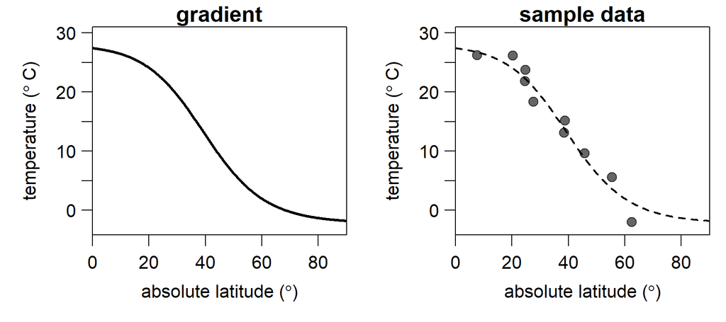

Now, we build a model that will reconstruct the gradient from the sample data. Before writing the main Markov chain Monte Carlo (MCMC) function, we pre-define a couple of supplementary functions that will make the code easier to read. We start with the log-likelihood function:

```r
loglik <- function(x, y,  coeff, sdy) {
  A = coeff[1]
  K = coeff[2]
  M = coeff[3]
  Q = coeff[4]
  nu = coeff[5]
  pred = A + max(c(K-A,0))/((1+(nu*exp(Q*(x-M))))^(1/nu))
  return(sum(dnorm(y, mean = pred, sd = sdy, log = TRUE)))
}
```

Next, we need a function to generate the log-priors. We specify the parameters of the prior distribution within the function for convenience. Uniform priors ranging from $-4$ to $40$ are put on $A$ and $K$, signifying that the temperature gradient cannot exceed this range. A normal prior with a mean of 45 standard deviation of $10$ is placed on $M$, implying that we expect the steepest temperature gradient in the mid-latitudes, but the data will quickly overwhelm the prior due to the large standard deviation. We constrain $Q$ and $\nu$ to be $>0$ by placing Gamma priors on them:

```r
logprior <- function(coeff) {
    return(sum(c(
    dunif(coeff[1], -4, 40, log = TRUE),
    dunif(coeff[2], -4, 40, log = TRUE),
    dnorm(coeff[3], 45, 10, log = TRUE),
    dgamma(coeff[4], 0.2, 0.2, log = TRUE),
    dgamma(coeff[5], 1, 1, log = TRUE))))
}
```

The posterior is proportional to the likelihood $\times$ prior. On the log scale, we can simply add them:

```r
logposterior <- function(x, y, coeff, sdy){
  return (loglik(x, y, coeff, sdy) + logprior(coeff))
}
```

Finally, we define a function that proposes new values for the Metropolis-Hastings step. The magnitude of the proposal standard deviations ($\sigma_{proposal}$) is quite important, as low values will lead to the chain exploring the parameter space very slowly, and high values result in a low acceptance rate and an insufficient exploration of the parameter space. As appropriate $\sigma_{proposal}$ are difficult to know a priori, adaptive steps are often used to find better values. For simplicity, we will use fixed $\sigma_{proposal}$. Different $\sigma_{proposal}$ can and usually should be used for different parameters.

```r
MH_propose <- function(coeff, proposal_sd){
  return(rnorm(5,mean = coeff, sd= c(.5,.5,.5,0.01,0.07)))
}
```

With all the prerequisites in place, we can build the MCMC function. The model will update $\sigma$ with a Gibbs step, and update the other coefficients with a Metropolis-Hastings step:

```r
run_MCMC <- function(x, y, coeff_inits, sdy_init, nIter){
  ### Initialisation
  coefficients = array(dim = c(nIter,5)) # set up array to store coefficients
  coefficients[1,] = coeff_inits # initialise coefficients
  sdy = rep(NA_real_,nIter) # set up vector to store sdy
  sdy[1] = sdy_init # intialise sdy
  A_sdy = 3 # parameter for the prior on the inverse gamma distribution of sdy
  B_sdy = 0.1 # parameter for the prior on the inverse gamma distribution of sdy
  n <- length(y)
  shape_sdy <- A_sdy+n/2 # shape parameter for the inverse gamma

  ### The MCMC loop
  for (i in 2:nIter){

    ## 1. Gibbs step to estimate sdy
    sdy[i] = sqrt(1/rgamma(1,shape_sdy,B_sdy+0.5*sum((y-gradient(x,coefficients[i-1,],0))^2)))

    ## 2. Metropolis-Hastings step to estimate the regression coefficients
    proposal = MH_propose(coefficients[i-1,]) # new proposed values
    if(any(proposal[c(4,5)] <= 0)) HR = 0 else # Q and nu need to be >0
    # Hasting's ratio of the proposal
    HR = exp(logposterior(x = x, y = y, coeff = proposal, sdy = sdy[i]) -
                   logposterior(x = x, y = y, coeff = coefficients[i-1,], sdy = sdy[i]))
    # accept proposal with probability = min(HR,1)
    if (runif(1) < HR){
      coefficients[i,] = proposal
    # if proposal is rejected, keep the values from the previous iteration
    }else{
      coefficients[i,] = coefficients[i-1,]
    }
  } # end of the MCMC loop

  ###  Function output
  output = data.frame(A = coefficients[,1],
                      K = coefficients[,2],
                      M = coefficients[,3],
                      Q = coefficients[,4],
                      nu = coefficients[,5],
                      sdy = sdy)
  return(output)
}
```

```r
nIter <- 100000
m <- run_MCMC(x = sample_data$x, y = sample_data$y, coeff_inits = c(10,20,30,0.4,0.4), sdy_init = 5, nIter = nIter)
```

To assess the model output, we produce trace plots and density plots of the posterior estimates of the parameters. For the trace plot, only every 10th iteration is shown to improve readability. We discard the first $10,000$ iterations as burn-in, to ensure we sample the posterior without the influence of the starting values.

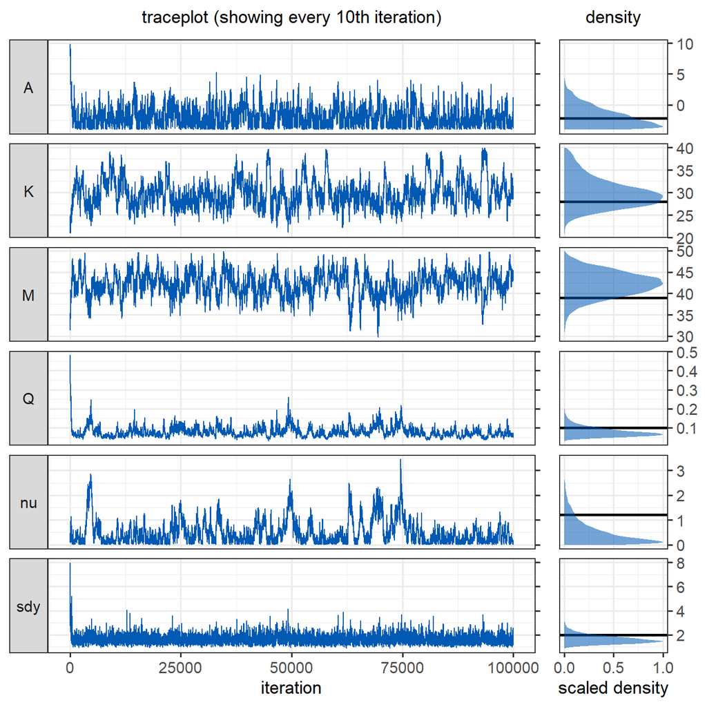

The parameters have converged reasonably well, except for $\nu$. We discard the first $10,000$ iterations as burn-in and use the mean of the parameters to plot the reconstructed gradient:

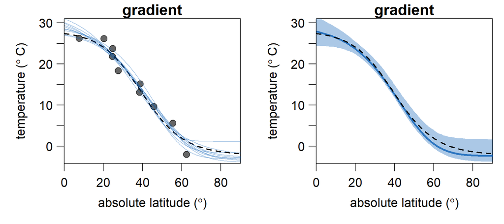